# Disciplina - DQF10440 Física D

## Aula em 11/02/2021 - Semestre 2020/2 EARTE

### [DQF - CCENS](http://alegre.ufes.br/ccens/departamento-de-quimica-e-fisica) - [UFES/Alegre](http://alegre.ufes.br/)

# Monitoria Voluntária

Foi divulgada hoje por email e mural da disciplina a monitoria voluntária de "Física D" nesse semestre 2020-2 EARTE.

Monitoria (voluntária) de Física D, por parte da aluna Isabella Moraes de Melo.  
Horários : 3a-feira 15h-17h, 5a-feira 15h-17h.  
[Link do canal no Discord](https://discord.gg/cc373FQXRa)  
Link da sala no Google Meet

# GitHub

### Crie seu repositório no [GitHub](https://github.com/)

É para conter exercícios de Física D : "FisicaD_Exercicios" ou nome semelhante, evitando acentuação e espaços (sugestão).

Crie como repositório privado ("Private"). Sugiro escolher usar "README.md" e licença "MIT".

Vá em "Settings -> Manage Access", clique no botão verde "Invite a collaborator" para adicionar o professor (conta "rcolistete") como colaborador do seu respositório privado.

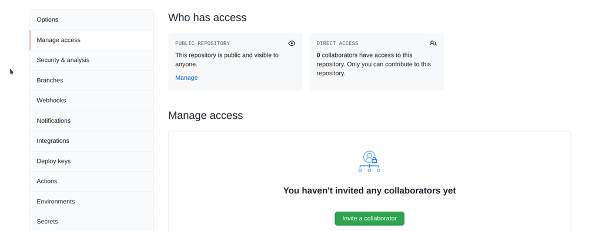

### Crie seu repositório no [GitHub](https://github.com/)

É para conter exercícios de Física D : "FisicaD_Exercicios" ou nome semelhante, evitando acentuação e espaços (sugestão).

Crie como repositório privado ("Private"). Sugiro escolher usar "README.md" e licença MIT.

Vá em "Settings -> Manage Access" e adicione o professor (conta "rcolistete") como colaborador do seu respositório privado.

# Ondas Eletromagnéticas - Espectro Eletromagnético

### Onda Eletromagnética = Radiação Eletromagnética = Luz !

São termos diferentes para o mesmo ente físico, por razões históricas.

( *Chamada para o princípio KISS* )

Luz pode ser visível ou invisível ao olho humano.

Quando que onda eletromagnética/radiação eletromagnética/luz faz mal ou não à saúde das pessoas, animais e plantas ?

Quando a energia do fóton (partícula dual associada à onda eletromagnética) foi alta demais, acima de certo limiar para o ser vivo em questão :

$$ E = h\,f = h\,\nu$$

onde $ h \approx (6,62607004 \times 10^{-34} J s)$ é a chamada constante de Planck da Física Quântica, e $ f = \nu$ é a frequência da onda eletromagnética.

( *Chamada da pronúncia do $\nu$ : vídeo dos "Cavaleiros que dizem ní".* )

Por isso é importantíssimo analisar o conjunto de frequências possíveis da luz (ondas eletromagnéticas), pois há faixas frequência que fazem mal à saude humana (etc), e outras não.

### Espectro da luz/eletromagnético

Tal conjunto de frequência possíveis da luz/ondas eletromagnéticas é o chamado espectro da luz/eletromagnético :

( *Chamada de Wolfram Demonstrations e Wolfram Player.* )

Wolfram Demonstration ["Colors of the Visible Spectrum"](https://demonstrations.wolfram.com/ColorsOfTheVisibleSpectrum/) mostra o espectro visível, com comprimento de onda $\lambda$ versus cores visíveis.

# Exercícios ao vivo sobre operadores diferenciais vetoriais

### Exercícios sobre aplicação prática dos operadores diferenciais vetoriais gradiente, divergente, rotacional

Não houve tempo para resolver mais exercícios listados em seguida, mas é para os alunos fazerem os exercícios ainda não feitos.

Depois será passada lista de exercícios mais completa sobre cálculos aplicadas a Física de gradiente, divergente e rotacional, a ser divulgada.

## Gradiente : $\vec{\nabla} f$

### Revisão

Gradiente é um operador diferencial vetorial que atua sobre função escalar e gera função vetorial.

Operador diferencial vetorial gradiente (grad) em coordenadas cartesianas 2D $(x, y)$ :

$$\vec{\nabla} = \left\langle \frac{\partial}{\partial x}, \frac{\partial}{\partial y}\right\rangle = \frac{\partial}{\partial x}\hat{i} + \frac{\partial}{\partial y}\hat{j} $$

em coordenadas polares $(\rho, \theta)$ :

$$\vec{\nabla} = \left\langle \frac{\partial }{\partial \rho},\frac{1}{\rho}\frac{\partial }{\partial \theta }\right\rangle = \frac{\partial }{\partial \rho}\hat{\rho} + \frac{1}{\rho}\frac{\partial }{\partial \theta }\hat{\theta}$$

em coordenadas cartesianas 3D $(x, y, z)$ :

$$\vec{\nabla}=\left\langle \frac{\partial }{\partial x}, \frac{\partial }{\partial y}, \frac{\partial }{\partial z}\right\rangle = \frac{\partial}{\partial x}\hat{i} + \frac{\partial}{\partial y}\hat{j} + \frac{\partial}{\partial z}\hat{k}$$

Em coordenadas cilíndricas $(\rho, \theta, z)$ :

$$\vec{\nabla}=\left\langle \frac{\partial }{\partial \rho},\frac{1}{\rho}\frac{\partial }{\partial \theta},\frac{\partial }{\partial z}\right\rangle = \frac{\partial }{\partial \rho}\hat{\rho} + \frac{1}{\rho}\frac{\partial }{\partial \theta }\hat{\theta} + \frac{\partial }{\partial z}\hat{k} $$

Em coordenadas esféricas $(r, \theta, \phi)$ :

$$\vec{\nabla}=\left\langle \frac{\partial }{\partial r},\frac{1}{r}\frac{\partial }{\partial \theta},\frac{1}{r sen \theta}\frac{\partial }{\partial \phi}\right\rangle = \frac{\partial }{\partial r}\hat{r} + \frac{1}{r}\frac{\partial }{\partial \theta}\hat{\theta} + \frac{1}{r sen \theta}\frac{\partial }{\partial \phi}\hat{\phi}$$

Funções escalares comuns no Eletromagnetismo, etc :

1) Potencial elétrico em um capacitor infinito de placas planas :

$$V(x)= k \,x$$

2) Potencial elétrico de uma carga elétrica :

$$V(r)=\frac{q}{4\,\pi \,\epsilon _{0}\,r}$$

3) Função genérica : $$V(r)=\frac{1}{r^{2}}$$

4) Potencial elétrico de um dipolo elétrico :

$$V(r,\theta )=\frac{p\,\cos \theta }{4\,\pi \,\epsilon _{0}\,r^{2}}$$

5) Potencial elétrico do átomo de Rutherford :

$$V(r)=\frac{Z\ e}{4\,\pi \,\epsilon _{0}\,}\left( \frac{1}{r}-\frac{3}{2R}+% \frac{r^{2}}{2R^{3}}\right)$$

### 1) [Exercícios ao vivo propostos aos alunos] Calcule gradiente :

1.a) do potencial (1) em coordenadas cartesianas 2D;

1.b) do potencial (2) em coordenadas cartesianas 3D e em coordenadas esféricas;

1.c) do potencial (3) em coordenadas cartesianas 3D, coordenadas cilíndricas e em coordenadas esféricas;

1.d) do potencial (4) em coordenadas cartesianas 2D e em coordenadas polares;

1.e) do potencial (5) em em coordenadas cartesianas 3D e em coordenadas esféricas;

#### Resolução :

Ex. 2 - coord. esféricas :

$$\vec{\nabla}\,V(r) = \frac{\partial\,V(r)}{\partial r}\hat{r} + \frac{1}{r}\frac{\partial \,V(r)}{\partial \theta}\hat{\theta} + \frac{1}{r sen \theta}\frac{\partial\,V(r)}{\partial \phi}\hat{\phi}$$

$$\vec{\nabla}\left(\frac{q}{4\,\pi \,\epsilon _{0}\,r}\right) = \frac{q}{4\,\pi \,\epsilon _{0}} \left[ \frac{\partial}{\partial r}\frac{1}{r}\hat{r} + \frac{1}{r}\frac{\partial }{\partial \theta}\frac{1}{r}\hat{\theta} + \frac{1}{r sen \theta}\frac{\partial}{\partial \phi}\frac{1}{r}\hat{\phi} \right]$$

$$\vec{\nabla}\left(\frac{q}{4\,\pi \,\epsilon _{0}\,r}\right) = \frac{q}{4\,\pi \,\epsilon _{0}} \left[ -\frac{1}{r^2}\hat{r} + 0\,\hat{\theta} + 0\,\hat{\phi} \right]$$

$$\vec{\nabla}\,V(r) = \vec{\nabla}\left(\frac{q}{4\,\pi \,\epsilon _{0}\,r}\right) = - \frac{q}{4\,\pi \,\epsilon_{0} r^2} \hat{r}$$

## Divergente : $\vec{\nabla} \cdot \vec{F}$

### Revisão

Divergente é um operador diferencial vetorial que atua sobre função vetorial e gera função escalar.

Em coordenadas cartesianas 3D $(x, y, z)$ :

$$\vec{\nabla} \cdot \vec{F} = \frac{\partial F_x}{\partial x} + \frac{\partial F_y}{\partial y} + \frac{\partial F_z}{\partial z} $$

em coordenadas cilíndricas $(\rho, \theta, z)$ :

$$\vec{\nabla} \cdot \vec{F} = \frac{1}{\rho}\frac{\partial\,(\rho F_{\rho})}{\partial \rho} + \frac{1}{\rho}\frac{\partial F_{\theta}}{\partial \theta} + \frac{\partial F_z}{\partial z} $$

em coordenadas esféricas $(r, \theta, \phi)$ :

$$\vec{\nabla} \cdot \vec{F} = \frac{1}{r^2} \frac{\partial\,(r^2 F_r)}{\partial r} + \frac{1}{r sen \theta}\frac{\partial\,(sen \theta F_{\theta})}{\partial \theta} + \frac{1}{r sen \theta}\frac{\partial F_\phi}{\partial \phi} $$

### 1) [Exercícios ao vivo propostos aos alunos] Calcule divergente :

1.a) Calcule o divergente em coordenadas esféricas, coordenadas cartesianas 3D e coordenadas cilíndricas. Ao final o resultado deve ser o mesmo, verifique. Sugestão, primeiro escreva a função vetorial (no caso o vetor posição $\vec{r}$) no sistema de coordenadas respectivo :

$$\vec{\nabla} \cdot \vec{r}$$

1.b) Calcule o divergente em coordenadas esféricas e coordenadas cilíndricas. Ao final o resultado deve ser o mesmo, verifique. Sugestão, primeiro escreva a função vetorial no sistema de coordenadas respectivo :

$$\vec{\nabla} \cdot \left( \frac{\hat{r}}{r} \right)$$

1.c) Calcule o divergente em coordenadas esféricas. Sem e com delta de Dirac :

$$\vec{\nabla} \cdot \left( \frac{\hat{r}}{r^2} \right)$$

1.a) Resolução do professor em coordenadas esféricas :

$$\vec{r} = r\,\hat{r} = \vec{F} = F_r \hat{r} + 0\,\hat{\theta} + 0\,\hat{\phi}$$$$F_r = r \quad,\quad F_{\theta} = 0 \quad,\quad F_\phi = 0 $$

Note que a expressão do divergente em coordenadas esféricas só é válida para $(r \ne 0\,m)$ e $(sen\,\theta \ne 0)$ :

$$\vec{\nabla} \cdot \vec{F} = \frac{1}{r^2} \frac{\partial\,(r^2 F_r)}{\partial r} + \frac{1}{r sen \theta}\frac{\partial\,(sen \theta F_{\theta})}{\partial \theta} + \frac{1}{r sen \theta}\frac{\partial\,F_\phi}{\partial \phi} $$

Logo :

$$\vec{\nabla} \cdot \vec{r} = \vec{\nabla} \cdot (r\,\hat{r}) = \frac{1}{r^2} \frac{\partial\,(r^2 r)}{\partial r} = 3 \frac{r^2}{r^2} = 3$$

Falta os alunos fazerem em coodenadas cartesianas 3D e cilíndricas para verificar que o resultado é o mesmo, igual a $3$.

O resultado de um operador diferencial vetorial não deve depender do sistema de coordenadas escolhido.